# Analyze A/B Test Results

#### *Student: Ryan S.*

- Introduction
- Part I - Probability
- Part II - A/B Test
- Part III - Regression

#### Please note:

My comments and written answers are in blue.

## Introduction

A/B tests are very commonly performed by data analysts and data scientists. For this project, you will be working to understand the results of an A/B test run by an e-commerce website. The company has developed a new web page in order to try and increase the number of users who "convert," meaning the number of users who decide to pay for the company's product. Your goal is to work through this notebook to help the company understand if they should implement this new page, keep the old page, or perhaps run the experiment longer to make their decision.

## Part I - Probability

To get started, import your libraries.

```python
import pandas as pd
import numpy as np
import random
import matplotlib.pyplot as plt
%matplotlib inline
import seaborn as sns

#Setting the seed to assure I get the same answers on quizzes that were set up
random.seed(42)

# This allows for the counting of values in arrays
import collections

import warnings
warnings.filterwarnings('ignore')

# Centers all charts in the document
from IPython.core.display import HTML
HTML("""
<style>
.output_png {
    display: table-cell;
    text-align: center;
    vertical-align: middle;
}
</style>
""")
```

## Question 1.

Now, read in the `ab_data.csv` data. Store it in `df`. **Use your dataframe to answer the questions in Quiz 1 of the classroom.**

### Q1a.

Read in the dataset and take a look at the top few rows here:

```python
df = pd.read_csv('ab_data.csv')
```

```python
df.head()
```

|  | user_id | timestamp | group | landing_page | converted |
| --- | --- | --- | --- | --- | --- |
| 0 | 851104 | 2017-01-21 22:11:48.556739 | control | old_page | 0 |
| 1 | 804228 | 2017-01-12 08:01:45.159739 | control | old_page | 0 |
| 2 | 661590 | 2017-01-11 16:55:06.154213 | treatment | new_page | 0 |
| 3 | 853541 | 2017-01-08 18:28:03.143765 | treatment | new_page | 0 |
| 4 | 864975 | 2017-01-21 01:52:26.210827 | control | old_page | 1 |

**Observations:**

This dataset contains five columns:

- **user_id** - A unique identifier for users visiting the website
- **timestamp** - Indicates when the user visited the website
- **group** - Indicates if the user was in the control or treatment group
- **landing_page** - Indicates which page the user was presented; if they are in the control group, they should receive the old_page, if they are in the treatment group they should receive the new_page
- **converted** - Indicates whether the user "converted" to purchasing the company's product; if the value is a 1, the user converted, 0 if they did not

### Q1b.

Use the below cell to find the number of rows in the dataset.

```python
len(df)
```

```
294478
```

### Q1c.

The number of unique users in the dataset.

```python
# I am using 'user_id' to find unique values
df.user_id.nunique()
```

```
290584
```

The number of unique user id's is less than the total rows so we have duplicates. Let's see how many.

```python
# Number of duplicate user_ids
df.user_id.duplicated().sum()
```

```
3894
```

### Q1d.

The proportion of users converted.

```python
# The number of times a value of 1 appears in the converted column divided by the length of the dataframe
df.query('converted == 1').shape[0]/len(df)
```

```
0.11965919355605512
```

```python
# You can also simply take the mean
df.converted.mean()
```

```
0.11965919355605512
```

### Q1e.

The number of times the `new_page` and `treatment` don't line up.

To clarify, we know that a user in the treatment group should receive the new page, and the control group should receive the old page. What this is really asking is, how many times did the treatment group receive the old page, and how many times the control group received the new page? In essence, we have two possible "bad" states, where both of the groups received the wrong landing page.

```python
# new page control and old page treatment individually
npc = df.query('landing_page == "new_page" and group == "control"').shape[0]
opt = df.query('landing_page == "old_page" and group == "treatment"').shape[0]
```

```python
# The number of people in the control group that got the incorrect (new) landing page
npc
```

```
1928
```

```python
# The number of people in the treatment group that got the incorrect (old) landing page
opt
```

```
1965
```

```python
# Total number of people in both groups that got the incorrect landing page
npc + opt
```

```
3893
```

You can also get this answer with one line of code, though I think this is more challenging to remember.

```python
len(df[((df['group'] == 'treatment') == (df['landing_page'] == 'new_page')) == False])
```

```
3893
```

### Q1f.

Do any of the rows have missing values?

```python
df.isnull().sum()
```

```
user_id         0
timestamp       0
group           0
landing_page    0
converted       0
dtype: int64
```

**Answer:** There are no missing values.

### Q1 Bonus Question

In the instructions, one of things we are told to consider is the length of time the test was administered. Since a cell was not included for this, I am adding it here.

How long was experiment run for?

```python
df.timestamp.min(), df.timestamp.max()
```

```
('2017-01-02 13:42:05.378582', '2017-01-24 13:41:54.460509')
```

**Answer:** The test ran for 22 days.

Back to Top

## Question 2.

For the rows where **treatment** is not aligned with **new_page** or **control** is not aligned with **old_page**, we cannot be sure if those rows truly received the correct corresponding page. Use **Quiz 2** in the classroom to provide how we should handle these rows.

### Q2a.

Now use the answer to the quiz to create a new dataset that meets the specifications from the quiz. Store your new dataframe in **df2**.

**Answer:** To solve this issue, I will create two temporary dataframes; one for the treatment group, and one for the control group, where each has only the appropriate landing pages. I will then concatenate these dataframes into one, effectively dropping all the rows where the wrong landing page was provided.

```python
# Create dataframe for the treatment group with the new page
temp1 = df.query('landing_page == "new_page" and group == "treatment"')
```

```python
# Create dataframe for the control group with the old page
temp2 = df.query('landing_page == "old_page" and group == "control"')
```

```python
# Concatenate the two temporary dataframes
df2 = pd.concat([temp1, temp2])
```

```python
# Getting a count of rows in each group
df2.groupby(['group', 'landing_page']).count()
```

| group | landing_page | user_id | timestamp | converted |
| --- | --- | --- | --- | --- |
| control | old_page | 145274 | 145274 | 145274 |
| treatment | new_page | 145311 | 145311 | 145311 |

```python
# Getting a total count of the group's combined rows
df2.user_id.shape[0]
```

```
290585
```

```python
# Verifying that all the "bad" rows were removed - this should equal zero
df2[((df2['group'] == 'treatment') == (df2['landing_page'] == 'new_page')) == False].shape[0]
```

```
0
```

Back to Top

## Question 3.

Use **df2** and the cells below to answer questions for **Quiz3** in the classroom.

### Q3a.

How many unique **user_id**s are in **df2**?

```python
df2.user_id.nunique()
```

```
290584
```

### Q3b.

There is one **user_id** repeated in **df2**. What is it?

```python
#df2.user_id.duplicated().value_counts()
```

```python
df2[df2.user_id.duplicated()]
```

|  | user_id | timestamp | group | landing_page | converted |
| --- | --- | --- | --- | --- | --- |
| 2893 | 773192 | 2017-01-14 02:55:59.590927 | treatment | new_page | 0 |

**Answer:** User ID 773192 is duplicated.

### Q3c.

What is the row information for the repeat **user_id**?

```python
# The row information was provided above when I identified the duplicate. So here's both rows to compare.
df2.query('user_id == 773192')
```

|  | user_id | timestamp | group | landing_page | converted |
| --- | --- | --- | --- | --- | --- |
| 1899 | 773192 | 2017-01-09 05:37:58.781806 | treatment | new_page | 0 |
| 2893 | 773192 | 2017-01-14 02:55:59.590927 | treatment | new_page | 0 |

### Q3d.

Remove **one** of the rows with a duplicate **user_id**, but keep your dataframe as **df2**.

```python
# Establishing the original number of rows in the dataframe
df2.shape[0]
```

```
290585
```

```python
# Dropping the duplicate row
df2 = df2.drop_duplicates(subset='user_id', keep='first')
```

```python
# Confirming the duplicate is gone
df2.query('user_id == 773192')
```

|  | user_id | timestamp | group | landing_page | converted |
| --- | --- | --- | --- | --- | --- |
| 1899 | 773192 | 2017-01-09 05:37:58.781806 | treatment | new_page | 0 |

```python
# Verifying that a row was removed from the dataframe
df2.shape[0]
```

```
290584
```

Back to Top

## Question 4.

Use **df2** in the below cells to answer the quiz questions related to **Quiz 4** in the classroom.

### Q4a.

What is the probability of an individual converting regardless of the page they receive?

In other words, what percent of the entire data frame contains converted users, i.e., the converted column contains a 1?

```python
# The number of times '1' appears in the converted column
df2.query('converted == 1').converted.count()
```

```
34753
```

```python
# The count of '1' appearing in the converted column divided by the length of the dataframe
df2.query('converted == 1').converted.count() / len(df2)
```

```
0.11959708724499628
```

It can also be done be simply taking the mean of the converted column.

```python
df2.converted.mean()
```

```
0.11959708724499628
```

### Q4b.

Given that an individual was in the `control` group, what is the probability they converted?

```python
# The count of rows where group equals control
df2.query('group == "control"').group.count()
```

```
145274
```

```python
# The count of zeros and ones in the converted column where group equals control
df2[df2.group == 'control'].converted.value_counts()
```

```
0    127785
1     17489
Name: converted, dtype: int64
```

```python
# Count of rows where group equals control and converted equals 1 divided by the number of rows with control for group
df2.query('group == "control" and converted == 1').converted.count() / df2.query('group == "control"').group.count()
```

```
0.1203863045004612
```

**Answer:** 0.1203863045004612

This could also be done by querying for where the group equals control and taking the mean of the converted column:

```python
df2.query('group == "control"').converted.mean()
```

```
0.1203863045004612
```

### Q4c.

Given that an individual was in the `treatment` group, what is the probability they converted?

This is the same as Q4b, but with the treatment group instead of the control group.

```python
# The count of rows where group equals treatment
df2.query('group == "treatment"').group.count()
```

```
145310
```

```python
# The count of zeros and ones in the converted column where group equals control
df2[df2.group == 'treatment'].converted.value_counts()
```

```
0    128046
1     17264
Name: converted, dtype: int64
```

```python
# Count of rows where group equals treatment and converted equals 1 divided by the number of rows with treatment for group
df2.query('group == "treatment" and converted == 1').converted.count() / df2.query('group == "treatment"').group.count()
```

```
0.11880806551510564
```

**Answer:** 0.11880806551510564

This could also be done by querying for where the group equals treatment and taking the mean of the converted column:

```python
df2.query('group == "treatment"').converted.mean()
```

```
0.11880806551510564
```

### Q4d.

What is the probability that an individual received the new page?

In other words, what percent of the entire dataframe contains rows where landing page equals `new_page`?

```python
# The count of new_page divided by the total rows
df2[df2.landing_page == 'new_page'].landing_page.count() / len(df2)
```

```
0.5000619442226688
```

```python
# The count of old_page divided by the total rows
df2[df2.landing_page == 'old_page'].landing_page.count() / len(df2)
```

```
0.4999380557773312
```

For all intents and purposes, this is a 50/50 split.

### Q4e.

Consider your results from a. through d. above, and explain below whether you think there is sufficient evidence to say that the new treatment page leads to more conversions.

**Answer:**

I do not think there is enough evidence to say the new page leads to more conversions:

- The probability of someone converting regardless of group was 11.96%
- The probability of someone converting from the control group was 12.04%
- The probability of someone converting from the treatment group was 11.88%

With all these probabilities being within 0.16% of each other, and the percents themselves being so low, I do not believe that conversion rates are related to the landing pages.

Back to Top

## Part II - A/B Test

Notice that because of the time stamp associated with each event, you could technically run a hypothesis test continuously as each observation was observed.

However, then the hard question is do you stop as soon as one page is considered significantly better than another or does it need to happen consistently for a certain amount of time? How long do you run to render a decision that neither page is better than another?

These questions are the difficult parts associated with A/B tests in general.

### Question 1.

For now, consider you need to make the decision just based on all the data provided. If you want to assume that the old page is better unless the new page proves to be definitely better at a Type I error rate of 5%, what should your null and alternative hypotheses be? You can state your hypothesis in terms of words or in terms of **$p_{old}$** and **$p_{new}$**, which are the converted rates for the old and new pages.

We are assuming that the *new page* is no better, or even worse than the *old page* at converting people; this is the **null** ($H_{0}$). Therefore, the **alternative** ($H_{1}$) is that the *new page* is better than the *old page* at converting people, which is the thing I am trying to prove.

To be more precise, we are assuming the conversion rate of customers who received the *new page* is no better, or even worse than the conversion rate of customers who received the *old page*.

Thus, the hypothesis is as follows:

$$\Large H_{0}: p_{new} - p_{old} \leq 0$$
$$\Large H_{1}: p_{new} - p_{old} > 0$$

```python
# I know that the control group contains only old_page and treatment contains only new_page
df2.groupby(['group', 'landing_page']).count()
```

| group | landing_page | user_id | timestamp | converted |
| --- | --- | --- | --- | --- |
| control | old_page | 145274 | 145274 | 145274 |
| treatment | new_page | 145310 | 145310 | 145310 |

In order to make things easier later on, I am creating two new dataframes; one for all the rows where group equals treatment, and one for all rows where group equals control. Remember that the `landing_page` column in the treatment group only contains *new_page*, while in the control group the column contains only *old_page*.

```python
# I am creating these dataframes for ease of use later
treatment = df2.query('group == "treatment"')
```

```python
control = df2.query('group == "control"')
```

### Question 2.

Assume under the null hypothesis, $p_{new}$ and $p_{old}$ both have "true" success rates equal to the **converted** success rate regardless of page - that is $p_{new}$ and $p_{old}$ are equal. Furthermore, assume they are equal to the **converted** rate in **ab_data.csv** regardless of the page.

Use a sample size for each page equal to the ones in **ab_data.csv**.

Perform the sampling distribution for the difference in **converted** between the two pages over 10,000 iterations of calculating an estimate from the null.

Use the cells below to provide the necessary parts of this simulation. If this doesn't make complete sense right now, don't worry - you are going to work through the problems below to complete this problem. You can use **Quiz 5** in the classroom to make sure you are on the right track.

**Note:**

Recall that I previously calculated the conversion rates for both groups, and since the treatment group only contains the new page, and control group only contains the old page, These are the true conversion rates for $p_{new}$ and $p_{old}$:

```python
# p_old
control.converted.mean()
```

```
0.1203863045004612
```

```python
# p_new
treatment.converted.mean()
```

```
0.11880806551510564
```

```python
# This is the observed difference in proportions
control.converted.mean() - treatment.converted.mean()
```

```
0.0015782389853555567
```

The difference between the conversion rates is 0.16%, which is essentially equal, which is why it is safe to make the assumption that $p_{new}$ and $p_{old}$ both have "true" success rates equal to the **converted** success rate regardless of page - that is $p_{new}$ and $p_{old}$ are equal. That is why in the next two questions, the entire dataframe is used rather than individualizing each by group/landing page.

Questions 2a through 2d are setting up variables to run some simulations.

### Q2a.

What is the **convert rate** for $p_{new}$ under the null?

```python
# The conversion rate is calculated by taking the mean of the converted column; i.e., the number of ones in the
#    converted column divided by the number of rows in the dataframe
p_new = df2.converted.mean()
p_new
```

```
0.11959708724499628
```

### Q2b.

What is the **convert rate** for $p_{old}$ under the null?

```python
# This is done the same way as in Q2a above
p_old = df2.converted.mean()
p_old
```

```
0.11959708724499628
```

### Q2c.

What is $n_{new}$?

```python
# I know that all new_page values are in the treatment group, so I can get the count using the treatment dataframe
n_new = treatment.shape[0]
n_new
```

```
145310
```

### Q2d.

What is $n_{old}$?

```python
# I know that all old_page values are in the control group, so I can get the count using the control dataframe
n_old = control.shape[0]
n_old
```

```
145274
```

### Q2e.

Simulate $n_{new}$ transactions with a convert rate of $p_{new}$ under the null. Store these $n_{new}$ 1's and 0's in **new_page_converted**.

```python
# This creates an array of ones and zeros
new_page_converted = np.random.binomial(1, p_new, n_new)
```

```python
# This counts the the number of each value in an array; in this case, 0 and 1
collections.Counter(new_page_converted)
```

```
Counter({0: 127697, 1: 17613})
```

### Q2f.

Simulate $n_{old}$ transactions with a convert rate of $p_{old}$ under the null. Store these $n_{old}$ 1's and 0's in **old_page_converted**.

```python
old_page_converted = np.random.binomial(1, p_old, n_old)
```

```python
collections.Counter(old_page_converted)
```

```
Counter({0: 127759, 1: 17515})
```

### Q2g.

Find $p_{new}$ - $p_{old}$ for your simulated values from part (e) and (f).

This is asking for the conversion rate of the **simulated** values from questions 2e and 2f. Both *new_page_converted* and *old_page_converted* are simply arrays with over 145,000 zeros or ones inside. Now the conversion rates for each have to be calculated and the difference calculated.

```python
# The conversion rate for the new page/treatment group
npcm = new_page_converted.mean()
npcm
```

```
0.12120982726584544
```

```python
# The conversion rate for the old page/control group
opcm = old_page_converted.mean()
opcm
```

```
0.12056527664964137
```

```python
# Subtracting the old page conversion rate from the new page conversion rate
sim_diff = npcm - opcm
sim_diff
```

```
0.0006445506162040676
```

The steps in 2e, 2f, and 2g can be run repeatedly, and the values will change slightly because it's sampling. What remains the same is that the difference between the new page conversion rate and the old page conversion rate is always a fraction of a percent, sometimes negative, sometimes positive. It is so close to zero that it there is no significant difference between the conversion rates. This indicates that the landing page has no effect on conversion rates.

### Q2h.

Simulate 10,000 $p_{new}$ - $p_{old}$ values using this same process similarly to the one you calculated in parts **a. through g.** above. Store all 10,000 values in a numpy array called **p_diffs**.

```python
new_converted_simulation = np.random.binomial(n_new, p_new, 10000)
new_converted_simulation
```

```
array([17419, 17278, 17421, ..., 17421, 17283, 17343])
```

This setup is slightly different than in 2e and 2f above. In plain terms, `random.binomial` essentially did a "coin flip" $n_{new}$ times, which is 145,310, and applied a probability of $p_{new}$ of getting a 1, which is 0.11959708724499628, and added up all the times it came up 1 and put it in the array, and did this 10,000 times. In this case, each value is always a little more than 17,000, which is what we saw in 2e and 2f above.

```python
new_converted_simulation / n_new
```

```
array([0.11987475, 0.11890441, 0.11988851, ..., 0.11988851, 0.11893882,
       0.11935173])
```

By dividing the array by $n_{new}$ (145,310), Python broadcasts $n_{new}$ for each value in the array and returns a proportion for each, i.e., it takes the mean for each value individually, as you can see above. So now it's an array of proportions instead a count of conversions.

This can be done in one step instead of two, by dividing by the `n` when running `random.binomial`:

```python
# The values will be different than above because this is a new simulation
new_converted_simulation = np.random.binomial(n_new, p_new, 10000) / n_new
new_converted_simulation
```

```
array([0.12117542, 0.11965453, 0.11869107, ..., 0.12031519, 0.12161586,
       0.11898011])
```

Above we did the new page simulation, below is the old page simulation.

```python
old_converted_simulation = np.random.binomial(n_old, p_old, 10000)/n_old
```

```python
old_converted_simulation
```

```
array([0.12041384, 0.12035877, 0.11928494, ..., 0.12068918, 0.11951898,
       0.11942261])
```

Lastly, the old conversion proportions are subtracted from the new conversion proportions, and now we have an array of **simulated differences in proportions**.

```python
p_diffs = new_converted_simulation - old_converted_simulation
```

```python
p_diffs
```

```
array([ 0.00076158, -0.00070424, -0.00059386, ..., -0.00037399,
        0.00209688, -0.0004425 ])
```

### Q2i.

Plot a histogram of the **p_diffs**. Does this plot look like what you expected? Use the matching problem in the classroom to assure you fully understand what was computed here.

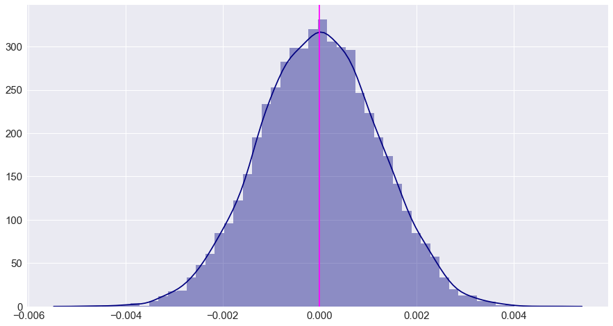

```python
plt.figure(figsize = (15,8))
sns.set(style="darkgrid", font_scale=1.5)
sns.distplot(p_diffs, color='navy');
plt.axvline(x=p_diffs.mean(), color = 'fuchsia'); # Provides the location of the mean in the distribution
```

This is the distribution of **p_diffs**, which is an array filled with the differences in the proportions between the *new page* and *old page*.

This is what I expected because the Central Limit Theorem states that with a large enough sample size, the sampling distribution of the difference in sample proportions will be normally distributed. We have 10,000 samples in the **p_diffs** array, which makes the central limit theorem apply here.

### Q2j.

What proportion of the **p_diffs** are greater than the actual difference observed in **ab_data.csv**?

<font color = #0033cc> Recall that the *treatment* and *control* dataframes contain all the data from their groups from the **df2** dataframe. Subtracting them from each other we provides the **observed difference**.

```python
tc = treatment.converted.mean()
tc
```

```
0.11880806551510564
```

```python
cc = control.converted.mean()
cc
```

```
0.1203863045004612
```

```python
# The observed difference in proportions (of converted users)
#    between the treatment/new page and control/old page groups
obs_diff = tc - cc
obs_diff
```

```
-0.0015782389853555567
```

This calculates which values in the **p_diffs** array are greater than the observed difference and returns a `true` or `false` value, and by taking the mean, it shows the proportion of true values. This is the p-value.

```python
pvalue = (p_diffs > obs_diff).mean()
pvalue
```

```
0.9017
```

**Answer:**

This means that over 90% of the **sampling differences (p_diffs)** are greater than the **observed difference**.

```python
# Count of the true/false values in the array
collections.Counter(p_diffs > obs_diff)
```

```
Counter({True: 9017, False: 983})
```

**Distribution**

Below is the distribution of **p_diffs** and where the **observed difference in proportion** falls (the green line). As stated, over 90% of the **sampling differences** are greater than the **observed difference**. This is reflected in the chart where the majority of the distribution falls to the right of the line.

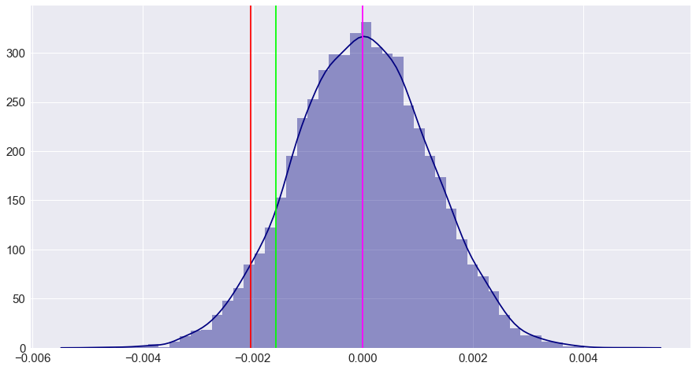

```python
plt.figure(figsize = (15,8))
sns.set(style="darkgrid", font_scale=1.5)
sns.distplot(p_diffs, color='navy');
ci = np.percentile(p_diffs, 5)
plt.axvline(x=obs_diff, color = 'lime');
plt.axvline(x=p_diffs.mean(), color = 'fuchsia')
plt.axvline(x=ci, color='red');
```

### Q2k.

In words, explain what you just computed in **2j** above. What is this value called in scientific studies? What does this value mean in terms of whether or not there is a difference between the new and old pages?

**Answer:**

In question **2j** we computed the **p-value**.

Consider:

**p_diffs** is an array that contains all of the simulated differences in proportions between conversion rates of the new and old page. It is the **sampling distribution**.

**obs_diff** is a **statistic**; a value where we took the proportion of users that converted when grouped by the *treatment (new page)* group and the proportion of users that converted when grouped by the *control (old page)* group and subtracted them to get the **observed difference in proportions**.

**p_diffs > obs_diff** is essentially taking every individual value from the **p_diffs** array, and comparing it to the value of **obs_diff** to see if the array values are larger. It then marks it as true or false. By using `.mean()`, we are getting the proportion of **True** values compared to the whole. This is the **p-value**.

The **p-value** of 0.90, or 90%, is strong evidence that the statistic came from the **null**, and that the null hypothesis is true; the *new page* is no better at converting customers than the *old page*. It far exceeds the Type 1 error threshold (the alpha - $\large \alpha$) of 5%, so it is **not** statistically significant. We **fail to reject the null**.

### Q2l.

We could also use a built-in to achieve similar results. Though using the built-in might be easier to code, the above portions are a walkthrough of the ideas that are critical to correctly thinking about statistical significance. Fill in the below to calculate the number of conversions for each page, as well as the number of individuals who received each page. Let `n_old` and `n_new` refer the the number of rows associated with the old page and new pages, respectively.

```python
# I previously set this up as the treatment and control dataframes, so I'll be using those instead
#n_old =
#n_new =

convert_old = control.query('converted == 1').shape[0]
convert_new = treatment.query('converted == 1').shape[0]
```

### Q2m.

Now use `stats.proportions_ztest` to compute your test statistic and p-value. [Here](http://knowledgetack.com/python/statsmodels/proportions_ztest/) is a helpful link on using the built in.

```python
import statsmodels.api as sm
```

```python
z_score, p_value = sm.stats.proportions_ztest([convert_new, convert_old], [n_new, n_old], alternative='larger')
z_score, p_value
```

```
(-1.3109241984234394, 0.9050583127590245)
```

We were not taught to use critical value in this course, but I am including it below as another way of confirming the results.

```python
from scipy.stats import norm

# Tells us how significant the z-score is
norm.cdf(z_score)
```

```
0.09494168724097551
```

```python
# Tells us the critical value at a 95% confidence interval
norm.ppf(1-(0.05))
```

```
1.6448536269514722
```

This could also be looked up in a Z table, however tables usually only go to 2 decimal places. My Z-table shows only 1.65 for this.

### Q2n.

What do the z-score and p-value you computed in the previous question mean for the conversion rates of the old and new pages? Do they agree with the findings in parts **j.** and **k.**?

Link to Q2j  
Link to Q2k

**Answer:**

A **z-score** of -1.3109 indicates the **observed difference in proportions** falls within *2 standard deviations* from the mean, so it is within the 95% confidence interval.

A **p-value** of 0.90 indicates the difference in conversion rates between the *control* and *treatment* groups does NOT appear to be significant. Therefore, we fail to reject the null hypothesis.

Additionally, the **z-score** is less than the **critical value** of 1.6449, which also indicates we fail to reject the null.

All of these findings agree with the findings above in parts **j** and **k**.

Back to Top

## Part III - A regression approach

In this final part, you will see that the result you achieved in the previous A/B test can also be achieved by performing regression.

### Q1a.

Since each row is either a conversion or not a conversion, what type of regression should you be performing in this case?

**Answer:**

I will be performing **Logistic Regression**.

The response (dependent) variable data is bivariate categorical data; either 0 or 1. Logistic Regression is used when trying to predict only two possible outcomes.

### Q1b.

The goal is to use **statsmodels** to fit the regression model you specified in part **a.** to see if there is a significant difference in conversion based on which page a customer receives. However, you first need to create a column for the intercept, and create a dummy variable column for which page each user received. Add an **intercept** column, as well as an **ab_page** column, which is 1 when an individual receives the **treatment** and 0 if **control**.

```python
# Adding the intercept
df2['intercept'] = 1
```

```python
df2.head()
```

|  | user_id | timestamp | group | landing_page | converted | intercept |
| --- | --- | --- | --- | --- | --- | --- |
| 2 | 661590 | 2017-01-11 16:55:06.154213 | treatment | new_page | 0 | 1 |
| 3 | 853541 | 2017-01-08 18:28:03.143765 | treatment | new_page | 0 | 1 |
| 6 | 679687 | 2017-01-19 03:26:46.940749 | treatment | new_page | 1 | 1 |
| 8 | 817355 | 2017-01-04 17:58:08.979471 | treatment | new_page | 1 | 1 |
| 9 | 839785 | 2017-01-15 18:11:06.610965 | treatment | new_page | 1 | 1 |

```python
# Getting dummies for the group column and assign "1" to the treatment group
df2['ab_page'] = pd.get_dummies(df2['group'])['treatment']
```

```python
# Confirming that "1" is assigned to the treatment group and "0" to the control group
df2.groupby(['group', 'ab_page']).count()
```

| group | ab_page | user_id | timestamp | landing_page | converted | intercept |
| --- | --- | --- | --- | --- | --- | --- |
| control | 0 | 145274 | 145274 | 145274 | 145274 | 145274 |
| treatment | 1 | 145310 | 145310 | 145310 | 145310 | 145310 |

```python
df2.head()
```

|  | user_id | timestamp | group | landing_page | converted | intercept | ab_page |
| --- | --- | --- | --- | --- | --- | --- | --- |
| 2 | 661590 | 2017-01-11 16:55:06.154213 | treatment | new_page | 0 | 1 | 1 |
| 3 | 853541 | 2017-01-08 18:28:03.143765 | treatment | new_page | 0 | 1 | 1 |
| 6 | 679687 | 2017-01-19 03:26:46.940749 | treatment | new_page | 1 | 1 | 1 |
| 8 | 817355 | 2017-01-04 17:58:08.979471 | treatment | new_page | 1 | 1 | 1 |
| 9 | 839785 | 2017-01-15 18:11:06.610965 | treatment | new_page | 1 | 1 | 1 |

### Q1c.

Use **statsmodels** to import your regression model. Instantiate the model, and fit the model using the two columns you created in part **b.** to predict whether or not an individual converts.

```python
import statsmodels.api as sm;
```

```python
# Instantiate the model
lr = sm.Logit(df2['converted'], df2[['intercept', 'ab_page']])
```

```python
# Fit the model
result = lr.fit()
```

```
Optimization terminated successfully.
         Current function value: 0.366118
         Iterations 6
```

### Q1d.

Provide the summary of your model below, and use it as necessary to answer the following questions.

```python
print(result.summary())
```

```
                           Logit Regression Results
==============================================================================
Dep. Variable:              converted   No. Observations:               290584
Model:                          Logit   Df Residuals:                   290582
Method:                           MLE   Df Model:                            1
Date:                Fri, 02 Aug 2019   Pseudo R-squ.:               8.077e-06
Time:                        15:43:10   Log-Likelihood:            -1.0639e+05
converged:                       True   LL-Null:                   -1.0639e+05
                                        LLR p-value:                    0.1899
==============================================================================
                 coef    std err          z      P>|z|      [0.025      0.975]
------------------------------------------------------------------------------
intercept     -1.9888      0.008   -246.669      0.000      -2.005      -1.973
ab_page       -0.0150      0.011     -1.311      0.190      -0.037       0.007
==============================================================================
```

```python
# provides the coefficients
result.params
```

```
intercept   -1.988777
ab_page     -0.014989
dtype: float64
```

```python
# Exponentiating the coefficients (instead of typing them in you can use .params)
np.exp(result.params)
```

```
intercept    0.136863
ab_page      0.985123
dtype: float64
```

```python
# Calculating the reciprocal
1/np.exp(result.params)
```

```
intercept    7.306593
ab_page      1.015102
dtype: float64
```

**Observation:**

Because this is logistic regression, the coefficients need to be exponentiated. And because the results are less than 1, we calculate the reciprocal.

For every one unit *decrease* in **ab_page**, conversion is 1.015 times as likely, holding all other variables constant. This result is negligible.

### Q1e.

What is the p-value associated with **ab_page**? Why does it differ from the value you found in **Part II**?  
**Hint**: What are the null and alternative hypotheses associated with your regression model, and how do they compare to the null and alternative hypotheses in the **Part II**?  
Link to Part II

**Answer:**

The reason the *p-values* are different between **Part II** and **Part III** has to do with the *hypotheses* used for each model. The **alternative** hypothesis dictates which type of test is used.

In **Part II**, the hypothesis is as follows:

$\large H_{0}: p_{new} - p_{old} \leq 0$  
$\large H_{1}: p_{new} - p_{old} > 0$

When the hypothesis is set up this way, it is a one-tailed test (specifically a *right-tailed test*). The test is directional; it is testing whether the conversion rate for the new page was greater than the old page or not. The A/B Test is using the explanatory variables of the treatment (new page) and control (old page) groups to predict the response variable, the conversion rate.

In **Part III**, the hypothesis is as follows:

$\large H_{0}: p_{new} - p_{old} = 0$  
$\large H_{1}: p_{new} - p_{old} \neq 0$

When the hypothesis is set up this way, it is a two-tailed test. It is non-directional; it is testing whether the new page has a conversion rate that is the same as the old page or not. If the conversion rates are not equal, then the landing pages have could have a positive **or** negative impact, which is why this is a two-tailed test. The logistic regression is measuring the probabilities of the conversion rate given the two possible landing pages.

### Q1f.

Now, you are considering other things that might influence whether or not an individual converts. Discuss why it is a good idea to consider other factors to add into your regression model. Are there any disadvantages to adding additional terms into your regression model?

**Answer:**

The dataset I have to work with only includes one additional piece of data, a timestamp. I could include this as the month/day or the time of day as a possible contributing factor in conversion, though logically it is not likely a very strong factor. There are other factors that I do not have access to, such as age, gender, income, education level, etc, that could be better at determining a conversion rate.

Adding additional terms to the regression model can have positive and negative effects. Adding *predictor (explanatory)* variables can improve the accuracy and the *R-squared* score. However, you have to check for *multicollinearity* among your predictor variables because if they are related to each other, it can overfit your model. More is not always better.

### Q1g.

Now along with testing if the conversion rate changes for different pages, also add an effect based on which country a user lives. You will need to read in the **countries.csv** dataset and merge together your datasets on the approporiate rows. [Here](https://pandas.pydata.org/pandas-docs/stable/generated/pandas.DataFrame.join.html) are the docs for joining tables.

Does it appear that country had an impact on conversion? Don't forget to create dummy variables for these country columns - **Hint: You will need two columns for the three dummy variables.** Provide the statistical output as well as a written response to answer this question.

```python
# Read in the new dataset
countries_df = pd.read_csv('./countries.csv')

# Merges the new dataset with the existing dataset on the user id
df_new = countries_df.set_index('user_id').join(df2.set_index('user_id'), how='inner')
```

```python
# Countries only contained a user_id and country column, so the join only added the country column to the existing df
df_new.columns
```

```
Index(['country', 'timestamp', 'group', 'landing_page', 'converted',
       'intercept', 'ab_page'],
      dtype='object')
```

```python
# The number of times each country appears in the dataframe
df_new.country.value_counts()
```

```
US    203619
UK     72466
CA     14499
Name: country, dtype: int64
```

There are only three values in the country column. These will be used to add dummies to the dataframe.

```python
# Create the necessary dummy variables
df_new[['CA', 'UK', 'US']] = pd.get_dummies(df_new['country'])
```

```python
df_new.head()
```

| user_id | country | timestamp | group | landing_page | converted | intercept | ab_page | CA | UK | US |
| --- | --- | --- | --- | --- | --- | --- | --- | --- | --- | --- |
| 834778 | UK | 2017-01-14 23:08:43.304998 | control | old_page | 0 | 1 | 0 | 0 | 1 | 0 |
| 928468 | US | 2017-01-23 14:44:16.387854 | treatment | new_page | 0 | 1 | 1 | 0 | 0 | 1 |
| 822059 | UK | 2017-01-16 14:04:14.719771 | treatment | new_page | 1 | 1 | 1 | 0 | 1 | 0 |
| 711597 | UK | 2017-01-22 03:14:24.763511 | control | old_page | 0 | 1 | 0 | 0 | 1 | 0 |
| 710616 | UK | 2017-01-16 13:14:44.000513 | treatment | new_page | 0 | 1 | 1 | 0 | 1 | 0 |

We have to exclude one of the dummy variables from our model. In this case I chose to exlude CA because it had the lowest count in the dataset.

```python
# Instantiate the model
lr2 = sm.Logit(df_new['converted'], df_new[['intercept', 'UK', 'US']])
```

```python
# Fit the model
result2 = lr2.fit()
```

```
Optimization terminated successfully.
         Current function value: 0.366116
         Iterations 6
```

```python
print(result2.summary())
```

```
                           Logit Regression Results
==============================================================================
Dep. Variable:              converted   No. Observations:               290584
Model:                          Logit   Df Residuals:                   290581
Method:                           MLE   Df Model:                            2
Date:                Fri, 02 Aug 2019   Pseudo R-squ.:               1.521e-05
Time:                        15:43:13   Log-Likelihood:            -1.0639e+05
converged:                       True   LL-Null:                   -1.0639e+05
                                        LLR p-value:                    0.1984
==============================================================================
                 coef    std err          z      P>|z|      [0.025      0.975]
------------------------------------------------------------------------------
intercept     -2.0375      0.026    -78.364      0.000      -2.088      -1.987
UK             0.0507      0.028      1.786      0.074      -0.005       0.106
US             0.0408      0.027      1.518      0.129      -0.012       0.093
==============================================================================
```

```python
# Exponentiate the coefficients
np.exp(result2.params)
```

```
intercept    0.130350
UK           1.052027
US           1.041647
dtype: float64
```

**Answer:**

Since the results are greater than 1, we do not need to calculate the reciprocal.

### Q1h.

Though you have now looked at the individual factors of country and page on conversion, we would now like to look at an interaction between page and country to see if there significant effects on conversion. Create the necessary additional columns, and fit the new model.

Provide the summary results, and your conclusions based on the results.

```python
# Instantiate the model
lr3 = sm.Logit(df_new['converted'], df_new[['intercept', 'ab_page', 'UK', 'US']])
```

```python
# Fit the model
result3 = lr3.fit()
```

```
Optimization terminated successfully.
         Current function value: 0.366113
         Iterations 6
```

```python
print(result3.summary())
```

```
                           Logit Regression Results
==============================================================================
Dep. Variable:              converted   No. Observations:               290584
Model:                          Logit   Df Residuals:                   290580
Method:                           MLE   Df Model:                            3
Date:                Fri, 02 Aug 2019   Pseudo R-squ.:               2.323e-05
Time:                        15:43:15   Log-Likelihood:            -1.0639e+05
converged:                       True   LL-Null:                   -1.0639e+05
                                        LLR p-value:                    0.1760
==============================================================================
                 coef    std err          z      P>|z|      [0.025      0.975]
------------------------------------------------------------------------------
intercept     -2.0300      0.027    -76.249      0.000      -2.082      -1.978
ab_page       -0.0149      0.011     -1.307      0.191      -0.037       0.007
UK             0.0506      0.028      1.784      0.074      -0.005       0.106
US             0.0408      0.027      1.516      0.130      -0.012       0.093
==============================================================================
```

```python
np.exp(result3.params)
```

```
intercept    0.131332
ab_page      0.985168
UK           1.051944
US           1.041599
dtype: float64
```

```python
1/np.exp(result3.params)
```

```
intercept    7.614303
ab_page      1.015056
UK           0.950621
US           0.960062
dtype: float64
```

**Answer:**

I calculated the reciprocal because one variable was just under 1, but it makes little difference. This model is a combination of the previous two, and the changes to the *coefficients* and *p-values* from the previous tests are miniscule. As with the previous tests, the landing page and country have no real impact conversion rates.

Back to Top

# Conclusions

For this project, I used three different methods to determine if the landing page had an impact on the number of customers who "convert" meaning they pay for the company's product:

- Probability Testing
- A/B Testing
- Logistic Regression Testing

### Probability Results

In the probability tests I found:

- The probability of someone converting regardless of group was 11.96%
- The probability of someone converting from the control group (the old page) was 12.04%
- The probability of someone converting from the treatment group (the new page) was 11.88%

With a conversion rate of ~12% for each group, I conclude that the landing page his little to no impact on conversion rates.

### A/B Test Results

For the A/B testing, I created a hypothesis:

$\large H_{0}: p_{new} - p_{old} \leq 0$  
$\large H_{1}: p_{new} - p_{old} > 0$

I created a sampling distribution of the difference in proportions using 10,000 samples, then compared it to the observed difference in proportions. I found that ~90% of the distribution was greater than the observed difference, which is the p-value, indicating that the statistic came from the null, and is therefore not significant. The result is that I fail to reject the null, so the landing page has little to no impact on conversion rates. </font>

### Logistic Regression Results

For the logistic regression testing, the hypothesis was as follows:

$\large H_{0}: p_{new} - p_{old} = 0$  
$\large H_{1}: p_{new} - p_{old} \neq 0$

I ran three different logistic regression models, comparing conversion rates with: </font>

- landing page
- country
- both landing page and country combined

### Final Summary

To summarize this project, each test confirmed the same result; that landing page has little to no impact on conversion rates. The experiment ran for 22 days, and yielded 290,584 unique users to run the tests against. With that many datapoints to work with, extending the experiment duration is unnecessary. Based on these results, implementing the new page or keeping the old page would be a purely aesthetic preference.

Back to Top